# Dataset generation: commented code

#### Parameters

```r
### Sales parameters ---------
sales_A <- 3000
startdate_A <- as.Date("2017/1/1")
enddate_A <- as.Date("2019/12/31")

sales_B <- 2000
startdate_B <- as.Date("2018/1/1")
enddate_B <- as.Date("2019/12/31")

### Device parts parameters ---------

parts_A <- c("K01", "S01")
parts_B <- c("K02", "S01")
```

Given these parameters, we can build the dataset that will serve as a basis for the remainder of this notebook. Most of what follows will consists in looping over this basic structure to enrich it with sales and failures data.

```r
(main_df <- tibble(
  terminal_model = c("A", "B"),
  total_sales = c(sales_A, sales_B),
  from = c(startdate_A, startdate_B),
  to = c(enddate_A, enddate_B)
))
```

| terminal_model | total_sales | from | to |
| --- | --- | --- | --- |
| A | 3000 | 2017-01-01 | 2019-12-31 |
| B | 2000 | 2018-01-01 | 2019-12-31 |

## Generate sales

For each device model $\mathcal{M} \in \{A,B\}$, a sequence of consecutive dates is generated from $startdate_{M}$ to $enddate_M$. Then, a sample of size $sales_M$ is randomly drawn with replacement from that sequence. Some trend and seasonality is deliberately created by the fact that at each stochastic iteration, the relative probability for a given date in the sequence to be picked depends on its position in the calendar year.

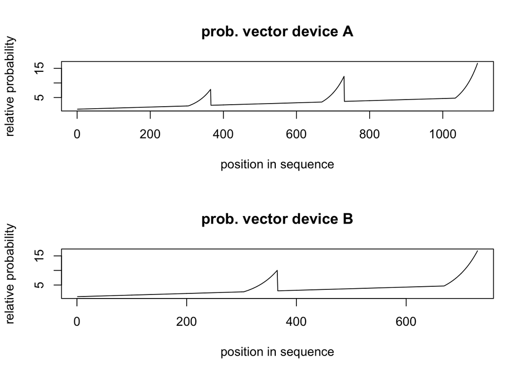

```r
sales_period_A <- as.numeric(enddate_A - startdate_A) + 1
sales_period_B <- as.numeric(enddate_B - startdate_B) + 1

# for simplicity, let's assume A and B have the same total sales growth over their respective sales period (1 tot 5)
probability_vector_A <-
  rep(c(rep(1,304),cumprod(rep(1.02, 61))), sales_period_A/365) * seq(from = 1, to = 5, length.out = sales_period_A)

probability_vector_B <-
  rep(c(rep(1,304),cumprod(rep(1.02, 61))), sales_period_B/365) * seq(from = 1, to = 5, length.out = sales_period_B)

par(mfrow=c(2,1))
plot.ts(probability_vector_A, ylab = "relative probability", xlab = "position in sequence", main = "prob. vector device A")
plot.ts(probability_vector_B, ylab = "relative probability", xlab = "position in sequence", main = "prob. vector device B")
```

Now I create and apply the function that generate the sales based on that logic :

```r
generate_sales <- function(totalsales, startdate, enddate){

  sales_period = as.numeric(enddate - startdate) + 1
  probability_vector = rep(c(rep(1,304),cumprod(rep(1.02, 61))), sales_period/365) * seq(from = 1, to = 5, length.out = sales_period)
  (sales <- sample(seq(from = startdate, to = enddate, by = "day"), size = totalsales, prob = probability_vector, replace = TRUE))
}

(main_df <- main_df %>%
  mutate(date_sold = pmap(list(total_sales, from, to), generate_sales)) %>%
  select(-c(from, to)))
```

| terminal_model | total_sales | date_sold |
| --- | --- | --- |
| A | 3000 |  |
| B | 2000 |  |

## Generate failures

In generating failures, I make the assumption that no part can live forever. Hence, each part $j$ of type $k \in \{"K01", "K02", "S01"\}$ has a theoretical time-to-failure $x_j^{theoretical}$ that is randomly drawn from a part-specific life length distribution $\mathcal{D_k}$. Yet, this failure might not occur for two reasons:

- A failure occured due to another part of the same device
- The failure date has not been reached yet

In this setting, the *observed time-to-failure* can be generated for each device $i$ that contains a set of parts $J_i$ as:

$$x^{obs}_i =
\begin{cases}
x_i = \min_{j \space \in J_i}(x_j^{theoretical})& \text{if } \space date\_sold_i + x_i \leq today \\
\emptyset & \text{otherwise}
\end{cases}$$
where $x_j^{theoretical} \sim \mathcal{D_k}$.

Then, the *reparation date* field is filled as follows:
$$reparation\_date_i =
\begin{cases}
date\_sold_i + x^{obs}_i& \text{if } \space \exists \space x_i^{obs}\\
\emptyset & \text{otherwise}
\end{cases}$$
I obtain the part-specific distributions $\mathcal{D_k}$ for $k \in \{"K01", "K02", "S01"\}$ by combining together skewed normal, truncated normal and uniform distributions. The goals here is to make these distributions heterogeneous and “unpure” enough so that methods based on over-simplifying assumptions are not misleadingly validated during the analysis phase.

This process also brings in the realistic challenge of right-censoring : we are less likely to observe the time-to-failure of longer-living devices. If not tackeled carefully, this could easily be a source of bias in the analysis.

```r
# Build function able to loop on part_codes and draw individual theoretical times-to-failure

generate_parts_failures <- function(part_code){
  if (part_code == "K01"){
    df = data.frame(
      failure_description = "Key not responding",
      timetofailure_theoretical = sample(
          c(rsn(n = 1, omega = 60, alpha = 10, tau = 0),  #Skewed normal
            rsn(n = 1, omega = -100, alpha = 5, tau = 10) + 400, #Skewed normal
            runif(1, min = 1, max = 5000)), # Uniform
            size = 1,
            prob = c(0.15,0.05, 0.8)
          )
    )
  }
  if (part_code == "K02"){
    df = data.frame(
      failure_description = "Key not responding",
      timetofailure_theoretical = sample(
          c(rsn(n = 1, omega = -100, alpha = 5, tau = 10) + 400, #Skewed normal
            runif(1, min = 1, max = 7000)), # Uniform
            size = 1,
            prob = c(0.05, 0.95)
          )
    )
  }
  if (part_code == "S01"){
    # might suffer from two types of failures
    if (sample(c("type1", "type2"), 1) == "type1"){
      df = data.frame(
            failure_description = "Screen flickering",
            timetofailure_theoretical = sample(
                c(rsn(n = 1, omega = -150, alpha = 10000, tau = .2) + 800, #Skewed normal
                  rtruncnorm(n = 1, mean = 800, sd = 600, a = 800)), #Truncated normal (only variates above average are kept)
                  size = 1,
                  prob = c(0.25, 0.75)
                )
            )
    }
    else{
      df = data.frame(
            failure_description = "Screen shutdown",
            timetofailure_theoretical = runif(1, min = 1, max = 2500) # Uniform
      )
    }
  }
  return(df %>% filter(timetofailure_theoretical >=0))
}



# Build function that, applied to main_df unnested:
# 1. splits a device in its parts;
# 2. applies the function generate_parts_failures() for each part;
# 3. computes the observed time-to-failure
# 4. computes the reparation date (when)

parts_df <- data.frame(
  terminal_model = c(rep("A", length(parts_A)), rep("B", length(parts_B))),
  part_code = c(parts_A, parts_B)
)

generate_reparation_dates <- function(model, date_sold){

  temporary_df<- filter(parts_df, terminal_model == model) %>%
  mutate(date_sold = date_sold)

  observed_failure <- temporary_df %>%
  mutate(timetofailure_theoretical = map(part_code, generate_parts_failures)) %>%
  unnest() %>%
  top_n(-1, timetofailure_theoretical) %>%
  mutate(failure_date = as.Date(
    ifelse(date_sold + ddays(timetofailure_theoretical) < Sys.time(),
           as.Date(date_sold + ddays(timetofailure_theoretical)),
           NA),
    origin="1970-01-01")) %>%
  mutate(failure_description = ifelse(is.na(failure_date), NA, failure_description)) %>%
  select(failure_description, failure_date)

  return(observed_failure)
}

## Apply the function:

source_df <- main_df %>%
  unnest() %>%
  mutate(reparation_date = map2(terminal_model, date_sold, generate_reparation_dates)) %>%
  unnest()

source_df %>%
  head(100)
```

| terminal_model | total_sales | date_sold | failure_description | failure_date |
| --- | --- | --- | --- | --- |
| A | 3000 | 2017-03-29 | Key not responding | 2018-09-12 |
| A | 3000 | 2019-09-14 | NA |  |
| A | 3000 | 2018-07-11 | Key not responding | 2018-09-25 |
| A | 3000 | 2018-12-29 | NA |  |
| A | 3000 | 2018-12-18 | NA |  |
| A | 3000 | 2018-10-25 | NA |  |
| A | 3000 | 2019-08-21 | NA |  |
| A | 3000 | 2019-02-11 | NA |  |
| A | 3000 | 2018-12-03 | Key not responding | 2019-03-29 |
| A | 3000 | 2019-10-27 | NA |  |

[output cut: 90 more lines]

Here is a summary of the observed failures in the obtained dataset.

```r
source_df %>%
  group_by(failure_description) %>%
  summarize(n = n())
```

| failure_description | n |
| --- | --- |
| Key not responding | 757 |
| Screen flickering | 80 |
| Screen shutdown | 315 |
| NA | 3848 |